# 3 分析手法

## 3.1 分析方針

分析は、プレイ回数と課金額を組み合わせた二値指標から始め、属性・ジャンルとの関係を調べた後、両指標の組み合わせを4状態に分けて内訳を検討する流れで進める。(1)指標の定義、(2)主要変数の分布確認、(3)ジャンル別集計、(4)属性を調整したロジスティック回帰を行い、続いて(5)4状態のジャンル比較、(6)年齢差の補助分析、(7)閾値の感度分析を行う。

研究題目に含まれる「過疎」「サービス終了リスク」の問題意識に対し、このCSVにはゲームごとの利用者数の推移、実際の離脱記録、サービス終了実績は含まれない。したがって、統計分析では「低プレイ・低課金の代理指標」または「低プレイ・低課金状態」と表記し、ゲームの過疎やサービス終了を直接測定したものとは解釈しない。また `SessionCount` の観測期間はCSVの項目から確認できないため、「週あたりのプレイ回数」とは呼ばない。

## 3.2 CSV読込

分析に用いる列を読み込み、文字列の空欄を欠損値に統一して、数値列を数値型に変換する。分析ごとに必要な変数が異なるため、対象者数は各分析で明示する。

**コード**

```r
csv_path <- "C:/Users/js201/OneDrive/ドキュメント/2026春/ゼミ2/データセット/mobile_game_inapp_purchases.csv"
raw_data <- read.csv(
  csv_path,
  check.names = FALSE,
  stringsAsFactors = FALSE,
  na.strings = c("", "NA")
)

required <- c("Age", "Country", "Device", "GameGenre",
              "SessionCount", "InAppPurchaseAmount")
missing_columns <- setdiff(required, names(raw_data))
if (length(missing_columns) > 0) {
  stop("CSVに必要な列がありません: ", paste(missing_columns, collapse = ", "))
}

clean_text <- function(x) {
  x <- trimws(as.character(x))
  x[x == ""] <- NA_character_
  x
}

d <- raw_data
categorical_columns <- c("Country", "Device", "GameGenre")
for (v in categorical_columns) d[[v]] <- clean_text(d[[v]])
numeric_columns <- c("Age", "SessionCount", "InAppPurchaseAmount")
for (v in numeric_columns) {
  d[[v]] <- suppressWarnings(as.numeric(d[[v]]))
}

cat("CSV全体:", nrow(d), "件\n")
```

```
CSV全体: 3024 件
```

**コード**

```r
cat("分析に使う列:\n")
```

```
分析に使う列:
```

**コード**

```r
str(d[required])
```

```
'data.frame':   3024 obs. of  6 variables:
 $ Age                : num  49 15 23 31 37 38 20 34 38 46 ...
 $ Country            : chr  "Norway" "Switzerland" "China" "Mexico" ...
 $ Device             : chr  "Android" "iOS" "Android" "Android" ...
 $ GameGenre          : chr  "Battle Royale" "Action RPG" "Fighting" "Racing" ...
 $ SessionCount       : num  9 11 9 12 10 16 9 15 10 18 ...
 $ InAppPurchaseAmount: num  11.4 6.37 15.81 13.49 10.86 ...
```

## 3.3 二値指標の分析対象と定義

二値指標による分析では、`Age`、`SessionCount`、`InAppPurchaseAmount` がそろうレコードを用いる。  
この対象内で両行動指標の第1四分位数を求め、各指標が境界以下なら「低い」とし、両方に該当する場合を1、該当しない場合を0とする。  
連続値・離散値の同値により、「境界以下」の実際の割合は必ずしも25%にならない。  
4状態の分析では年齢を必須にせず、プレイ回数と課金額がそろう全対象を用いるため、標本・境界が異なる。

**コード**

```r
base_data <- d[complete.cases(d[c("SessionCount", "InAppPurchaseAmount")]), ]
prior_data <- d[complete.cases(d[c("Age", "SessionCount", "InAppPurchaseAmount")]), ]
play_cutoff <- unname(quantile(prior_data$SessionCount, 0.25, type = 7))
spend_cutoff <- unname(quantile(prior_data$InAppPurchaseAmount, 0.25, type = 7))

prior_data$low_play <- prior_data$SessionCount <= play_cutoff
prior_data$low_spend <- prior_data$InAppPurchaseAmount <= spend_cutoff
prior_data$low_both <- as.integer(prior_data$low_play & prior_data$low_spend)

data.frame(
  分析対象 = nrow(prior_data),
  プレイ回数の第1四分位境界 = play_cutoff,
  課金額の第1四分位境界 = spend_cutoff,
  該当者数 = sum(prior_data$low_both == 1),
  該当割合_percent = mean(prior_data$low_both == 1) * 100
)
```

| 分析対象 | プレイ回数の第1四分位境界 | 課金額の第1四分位境界 | 該当者数 | 該当割合_percent |
| --- | --- | --- | --- | --- |
| 2835 | 8 | 6.01 | 216 | 7.619048 |

プレイ回数が8回以下、かつ課金額が約6.01ドル以下の人を「両方低い」と判定する。

## 3.4 主要変数の分布確認

二値指標から4状態へ進む分析の土台として、プレイ回数と課金額の要約統計量および分布を示す。課金額は分布の裾が長い可能性があるため、平均だけでなく中央値と四分位数も確認する。

**コード**

```r
make_summary <- function(x, variable_name) {
  result <- data.frame(
    変数 = variable_name,
    有効件数 = length(x),
    平均 = mean(x),
    標準偏差 = sd(x),
    第1四分位数 = unname(quantile(x, 0.25)),
    中央値 = median(x),
    第3四分位数 = unname(quantile(x, 0.75)),
    最小値 = min(x),
    最大値 = max(x)
  )

  result[, -1] <- lapply(result[, -1], round, 2)
  result
}

# プレイ回数の表
session_table <- make_summary(
  prior_data$SessionCount,
  "SessionCount"
)
session_table
```

| 変数 | 有効件数 | 平均 | 標準偏差 | 第1四分位数 | 中央値 | 第3四分位数 | 最小値 | 最大値 |
| --- | --- | --- | --- | --- | --- | --- | --- | --- |
| SessionCount | 2835 | 10.07 | 3.13 | 8 | 10 | 12 | 1 | 22 |

**コード**

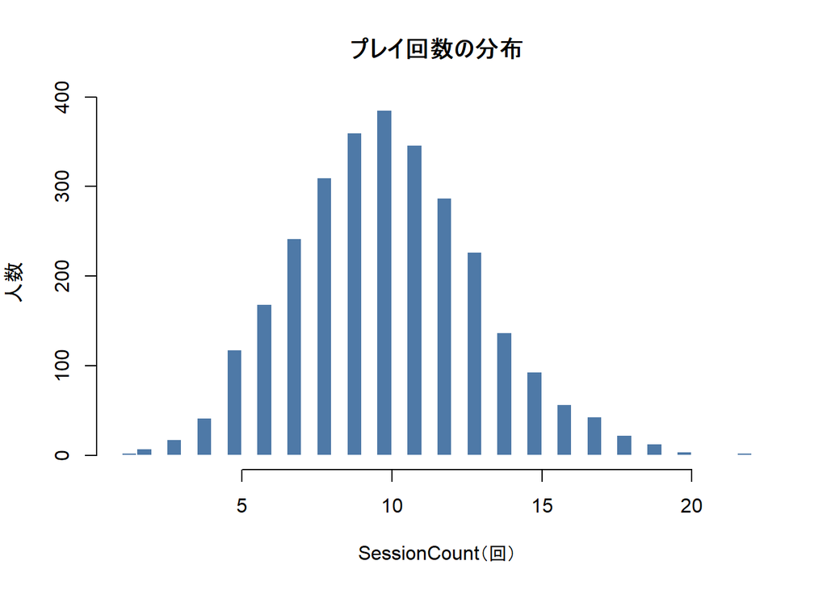

```r
hist(
  base_data$SessionCount,
  breaks = "FD",
  col = "#4E79A7",
  border = "white",
  main = "プレイ回数の分布",
  xlab = "SessionCount（回）",
  ylab = "人数")
```

プレイ回数は、中央値が10回で、第1四分位数が8回、第3四分位数が12回。中央の半数のユーザーはおおむね8∼12回の範囲にいる。

**コード**

```r
# 課金額の表
spending_table <- make_summary(
  prior_data$InAppPurchaseAmount,
  "InAppPurchaseAmount"
)
spending_table
```

| 変数 | 有効件数 | 平均 | 標準偏差 | 第1四分位数 | 中央値 | 第3四分位数 | 最小値 | 最大値 |
| --- | --- | --- | --- | --- | --- | --- | --- | --- |
| InAppPurchaseAmount | 2835 | 103.76 | 458.25 | 6.01 | 11.99 | 17.78 | 0 | 4964.45 |

**コード**

```r
d <- read.csv(
  "C:/Users/js201/OneDrive/ドキュメント/2026春/ゼミ2/データセット/mobile_game_inapp_purchases.csv",
  na.strings = c("", "NA")
)

x <- as.numeric(d$InAppPurchaseAmount)
x <- x[is.finite(x)]

cat("有効件数:", length(x), "\n")
```

```
有効件数: 2888
```

**コード**

```r
cat("範囲:", range(x), "\n")
```

```
範囲: 0 4964.45
```

**コード**

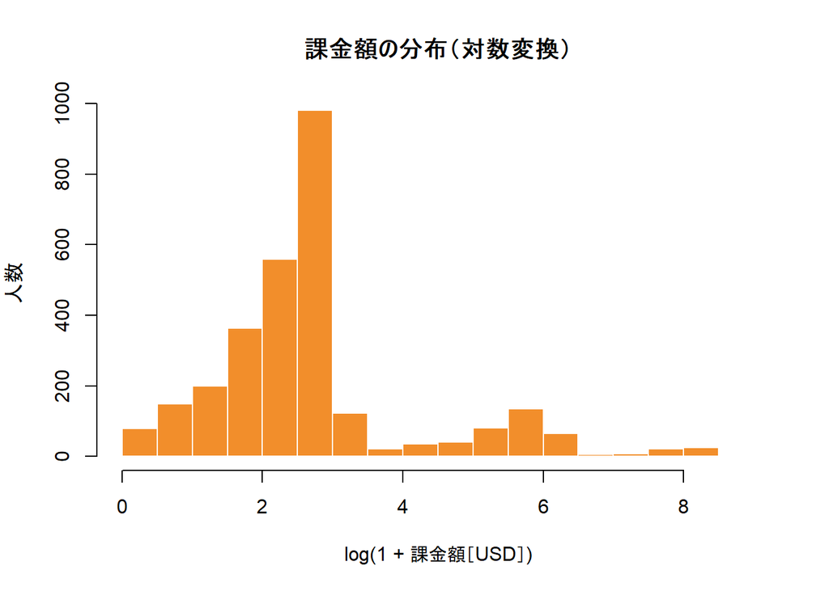

```r
hist(
  log1p(x),
  breaks = 30,
  col = "#F28E2B",
  border = "white",
  main = "課金額の分布（対数変換）",
  xlab = "log(1 + 課金額［USD］)",
  ylab = "人数"
)
```

課金額は、中央値が11.99ドルなのに対し、平均が103.76ドル。最大値も4,964.45ドルと大きく、少数の高額課金が平均を押し上げている、偏りの大きい分布だと考えられる。そのため、課金額は平均だけではなく中央値や四分位数も併せてみる必要がある。 ＊グラフは対数変換されている。

## 3.5 ジャンル別の単純集計

二値指標（両方低い／それ以外）を用い、ゲームジャンルごとの人数と該当割合を算出する。割合だけでは少数ジャンルが目立つ場合があるため、分母となる人数も併記する。これは記述的な比較であり、ジャンルの因果効果を推定するものではない。

**コード**

```r
genre_data <- prior_data[!is.na(prior_data$GameGenre), ]
genre_split <- split(genre_data, genre_data$GameGenre)
genre_summary <- do.call(rbind, lapply(names(genre_split), function(g) {
  x <- genre_split[[g]]
  n <- nrow(x)
  k <- sum(x$low_both == 1)
  ci <- if (n > 0) binom.test(k, n)$conf.int else c(NA_real_, NA_real_)
  data.frame(
    GameGenre = g,
    人数 = n,
    該当者数 = k,
    該当割合_percent = 100 * k / n,
    CI95下限_percent = 100 * ci[1],
    CI95上限_percent = 100 * ci[2]
  )
}))
genre_summary <- genre_summary[order(-genre_summary$該当割合_percent), ]
genre_summary[, -1] <- lapply(genre_summary[, -1], round, 2)
rownames(genre_summary) <- NULL
genre_summary
```

| GameGenre | 人数 | 該当者数 | 該当割合_percent | CI95下限_percent | CI95上限_percent |
| --- | --- | --- | --- | --- | --- |
| Sandbox | 204 | 20 | 9.80 | 6.09 | 14.73 |
| Sports | 207 | 20 | 9.66 | 6.00 | 14.53 |
| Role Playing | 182 | 17 | 9.34 | 5.54 | 14.53 |
| MMORPG | 183 | 17 | 9.29 | 5.51 | 14.46 |
| Action RPG | 179 | 16 | 8.94 | 5.20 | 14.11 |
| Adventure | 159 | 14 | 8.81 | 4.90 | 14.33 |
| Simulation | 206 | 18 | 8.74 | 5.26 | 13.46 |
| Fighting | 171 | 13 | 7.60 | 4.11 | 12.65 |
| Battle Royale | 175 | 13 | 7.43 | 4.01 | 12.37 |
| Racing | 181 | 13 | 7.18 | 3.88 | 11.97 |

[output cut: 5 more lines]

**コード**

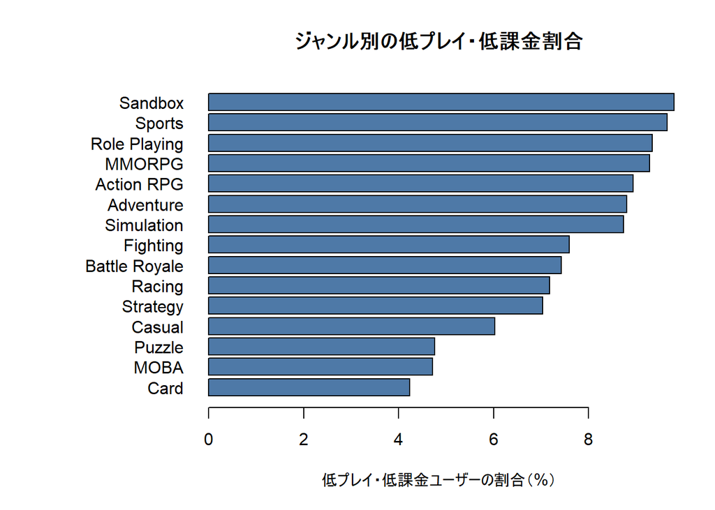

```r
plot_data <- genre_summary[order(genre_summary$該当割合_percent), ]
par(mar = c(5, 10, 4, 2))
barplot(plot_data$該当割合_percent, names.arg = plot_data$GameGenre,
        horiz = TRUE, las = 1, col = "#4E79A7",
        xlab = "低プレイ・低課金ユーザーの割合（%）",
        main = "ジャンル別の低プレイ・低課金割合")
```

**コード**

```r
par(mar = c(5, 4, 4, 2))
```

割合はSandboxが9.80%で最も高く、Sportsが9.66%。Cardは4.23%で最も低くなっている。

## 3.6 属性を調整したロジスティック回帰

目的変数はプレイ回数と課金額から作る二値代理指標である。  
年齢・国・端末・ジャンルを説明変数として、各属性と該当状態との関連を同時に推定する。  
目的変数作成に使う行と、説明変数の欠損を除いた回帰標本は異なるため、回帰に用いた標本数と該当者数を報告する。  
カテゴリ変数の係数はそれぞれ基準カテゴリとの比較であり、変数全体の検定結果も確認する。

**コード**

```r
model_columns <- c("low_both", "Age", "Country", "Device", "GameGenre")
model_data <- prior_data[
  complete.cases(prior_data[model_columns]) &
    !is.na(prior_data$Country) & !is.na(prior_data$Device) &
    !is.na(prior_data$GameGenre),
]

model_data$Country <- droplevels(factor(model_data$Country))
model_data$Device <- droplevels(factor(model_data$Device))
model_data$GameGenre <- droplevels(factor(model_data$GameGenre))

cat("回帰標本:", nrow(model_data), "件\n")
```

```
回帰標本: 2667 件
```

**コード**

```r
cat("該当者:", sum(model_data$low_both == 1), "人\n")
```

```
該当者: 204 人
```

**コード**

```r
cat("非該当者:", sum(model_data$low_both == 0), "人\n")
```

```
非該当者: 2463 人
```

**コード**

```r
logit_model <- glm(
  low_both ~ Age + Country + Device + GameGenre,
  data = model_data,
  family = binomial(link = "logit")
)
summary(logit_model)
```

```
Call:
glm(formula = low_both ~ Age + Country + Device + GameGenre,
    family = binomial(link = "logit"), data = model_data)

Coefficients:
                         Estimate Std. Error z value Pr(>|z|)
(Intercept)            -2.2899557  0.5117746  -4.475 7.66e-06 ***
Age                     0.0009323  0.0061462   0.152    0.879
CountryAustralia       -0.1175860  0.5264048  -0.223    0.823
CountryBangladesh      -0.2480927  0.5430965  -0.457    0.648
CountryBrazil          -0.3708817  0.5646857  -0.657    0.511
CountryCanada          -0.7416280  0.6361334  -1.166    0.244
CountryChina            0.4669768  0.4880409   0.957    0.339
CountryDenmark          0.0483159  0.5137279   0.094    0.925
CountryEgypt            0.3115810  0.4938423   0.631    0.528
CountryFrance           0.3384595  0.5043362   0.671    0.502
CountryGermany          0.2881337  0.4850736   0.594    0.553
CountryIndia           -0.1396408  0.4476551  -0.312    0.755
CountryIran             0.0191049  0.5126250   0.037    0.970
CountryItaly           -0.2729703  0.5428645  -0.503    0.615
CountryJapan           -0.3045195  0.5417188  -0.562    0.574
CountryMexico          -0.8576379  0.6338683  -1.353    0.176
CountryNetherlands     -0.8516727  0.6330903  -1.345    0.179
CountryNorway          -0.6428624  0.5932210  -1.084    0.279
CountryRussia          -0.6508596  0.6355440  -1.024    0.306
CountrySaudi Arabia    -0.9786600  0.6331121  -1.546    0.122
CountrySouth Korea     -0.5759207  0.5934663  -0.970    0.332
CountrySpain            0.2477420  0.5040187   0.492    0.623
CountrySri Lanka        0.2455859  0.5170316   0.475    0.635
CountrySweden          -0.8022252  0.6343912  -1.265    0.206
CountrySwitzerland     -0.0010117  0.5010850  -0.002    0.998
CountryTurkey          -0.6052620  0.6372312  -0.950    0.342
CountryUK              -0.3144680  0.5418936  -0.580    0.562
CountryUSA             -0.3053011  0.5651101  -0.540    0.589
DeviceiOS               0.0187875  0.1508747   0.125    0.901
GameGenreAdventure      0.1332538  0.3992959   0.334    0.739
GameGenreBattle Royale -0.1639530  0.4229853  -0.388    0.698
GameGenreCard          -0.6420685  0.4603850  -1.395    0.163
GameGenreCasual        -0.2320752  0.4116757  -0.564    0.573
GameGenreFighting      -0.0666078  0.4046664  -0.165    0.869
GameGenreMMORPG         0.2108583  0.3826181   0.551    0.582
GameGenreMOBA          -0.5362842  0.4611178  -1.163    0.245
GameGenrePuzzle        -0.4789984  0.4453959  -1.075    0.282
GameGenreRacing        -0.1618104  0.4134277  -0.391    0.696
GameGenreRole Playing   0.2353522  0.3824177   0.615    0.538
GameGenreSandbox        0.1740046  0.3726262   0.467    0.641
GameGenreSimulation     0.1449773  0.3764753   0.385    0.700
GameGenreSports         0.2150631  0.3692756   0.582    0.560
GameGenreStrategy      -0.2009578  0.4128890  -0.487    0.626
---
Signif. codes:  0 '***' 0.001 '**' 0.01 '*' 0.05 '.' 0.1 ' ' 1

(Dispersion parameter for binomial family taken to be 1)

    Null deviance: 1440.8  on 2666  degrees of freedom
Residual deviance: 1398.9  on 2624  degrees of freedom
AIC: 1484.9

Number of Fisher Scoring iterations: 5
```

係数はオッズ比に変換し、95% Wald信頼区間とp値を示す。

**コード**

```r
coef_mat <- coef(summary(logit_model))
or_table <- data.frame(
  変数 = rownames(coef_mat),
  係数 = coef_mat[, "Estimate"],
  標準誤差 = coef_mat[, "Std. Error"],
  オッズ比 = exp(coef_mat[, "Estimate"]),
  CI95下限 = exp(coef_mat[, "Estimate"] - 1.96 * coef_mat[, "Std. Error"]),
  CI95上限 = exp(coef_mat[, "Estimate"] + 1.96 * coef_mat[, "Std. Error"]),
  p値 = coef_mat[, "Pr(>|z|)"],
  row.names = NULL
)
or_table[, -1] <- lapply(or_table[, -1], round, 4)
or_table
```

| 変数 | 係数 | 標準誤差 | オッズ比 | CI95下限 | CI95上限 | p値 |
| --- | --- | --- | --- | --- | --- | --- |
| (Intercept) | -2.2900 | 0.5118 | 0.1013 | 0.0371 | 0.2761 | 0.0000 |
| Age | 0.0009 | 0.0061 | 1.0009 | 0.9889 | 1.0131 | 0.8794 |
| CountryAustralia | -0.1176 | 0.5264 | 0.8891 | 0.3168 | 2.4947 | 0.8232 |
| CountryBangladesh | -0.2481 | 0.5431 | 0.7803 | 0.2691 | 2.2623 | 0.6478 |
| CountryBrazil | -0.3709 | 0.5647 | 0.6901 | 0.2282 | 2.0874 | 0.5113 |
| CountryCanada | -0.7416 | 0.6361 | 0.4763 | 0.1369 | 1.6573 | 0.2437 |
| CountryChina | 0.4670 | 0.4880 | 1.5952 | 0.6129 | 4.1518 | 0.3386 |
| CountryDenmark | 0.0483 | 0.5137 | 1.0495 | 0.3834 | 2.8726 | 0.9251 |
| CountryEgypt | 0.3116 | 0.4938 | 1.3656 | 0.5187 | 3.5949 | 0.5281 |
| CountryFrance | 0.3385 | 0.5043 | 1.4028 | 0.5220 | 3.7696 | 0.5022 |

[output cut: 33 more lines]

**コード**

```r
# 各カテゴリ変数を全体として評価する尤度比検定
drop1(logit_model, test = "Chisq")
```

|  | Df | Deviance | AIC | LRT | Pr(>Chi) |
| --- | --- | --- | --- | --- | --- |
|  | NA | 1398.927 | 1484.927 | NA | NA |
| Age | 1 | 1398.950 | 1482.950 | 0.02300619 | 0.8794410 |
| Country | 26 | 1427.687 | 1461.687 | 28.75993645 | 0.3221115 |
| Device | 1 | 1398.943 | 1482.943 | 0.01549074 | 0.9009497 |
| GameGenre | 14 | 1411.836 | 1469.836 | 12.90895825 | 0.5337046 |

**コード**

```r
data.frame(
  回帰標本数 = nobs(logit_model),
  該当者数 = sum(model_data$low_both == 1),
  非該当者数 = sum(model_data$low_both == 0),
  AIC = AIC(logit_model),
  null_deviance = logit_model$null.deviance,
  residual_deviance = logit_model$deviance
)
```

| 回帰標本数 | 該当者数 | 非該当者数 | AIC | null_deviance | residual_deviance |
| --- | --- | --- | --- | --- | --- |
| 2667 | 204 | 2463 | 1484.927 | 1440.783 | 1398.927 |

| 項目 | 出力の場所 | 数値 | 読み取り方 |
| --- | --- | --- | --- |
| 回帰分析の対象人数 | 回帰標本数 | 2,667人 | 年齢・国・端末・ジャンルなど、モデルに使う情報がそろった人数 |
| 回帰分析での該当者数 | 該当者数 | 204人 | 回帰標本のうち、低プレイ・低課金の両方に該当した人数 |
| 年齢のオッズ比 | `or_table` のAge行「オッズ比」 | 1.0009 | 年齢が1歳上がったとき、該当するオッズがわずかに高くなる推定。ただし、ほぼ1に近い |
| 年齢の95%信頼区間 | `or_table` のAge行「CI95下限～CI95上限」 | 0.9889～1.0131 | 1を含んでいる |
| 年齢との個別の関連 | `summary(logit_model)` のAge行 `Pr(>\\|z\\|)` | p = 0.879 | 5%水準を上回り、年齢との個別の関連は確認できない |
| 年齢との全体的な関連 | `drop1()` のAge行 `Pr(>Chi)` | p = 0.8794 | 年齢をモデルから除いても、適合度に明確な変化は確認できない |
| 国全体との関連 | `drop1()` のCountry行 `Pr(>Chi)` | p = 0.3221 | 国全体としての明確な関連は確認できない |
| 端末全体との関連 | `drop1()` のDevice行 `Pr(>Chi)` | p = 0.9009 | 端末全体としての明確な関連は確認できない |
| ジャンル全体との関連 | `drop1()` のGameGenre行 `Pr(>Chi)` | p = 0.5337 | ジャンル全体としての明確な関連は確認できない |

回帰分析の対象は2,667人で、そのうち低プレイ・低課金の両方に該当した人は204人だった。 年齢のオッズ比は1.0009、95%信頼区間は0.9889∼1.0131で、信頼区間は1を含んでいる。 年齢のp値も個別の係数検定で0.879、変数全体の検定で0.8794となり、年齢との明確な関連は確認できなかった。

国・端末・ジャンルについても、変数全体の検定結果はそれぞれp = 0.3221、p = 0.9009、p = 0.5337で、いずれも5%水準を上回っている。 したがって、この分析では、年齢・国・端末・ジャンルと低プレイ・低課金の代理指標との明確な関連は確認できなかった。

## 3.7 4状態の定義

二値指標で捉えた状態をさらに詳しく見るため、年齢を必須とせず、プレイ回数と課金額がそろう対象を用いて、それぞれの第1四分位数を計算する。 プレイ回数と課金額の低さを別々に扱い、二つの二値指標の組み合わせから4状態を作る。同じ境界値を含むユーザーは「低い」側に分類する。

| 状態 | プレイ回数 | 課金額 |
| --- | --- | --- |
| 低プレイのみ | 低い | 低くない |
| 低課金のみ | 低くない | 低い |
| 低プレイ・低課金の両方 | 低い | 低い |
| どちらも低くない | 低くない | 低くない |

**コード**

```r
play_cutoff_4state <- unname(quantile(base_data$SessionCount, 0.25, type = 7))
spend_cutoff_4state <- unname(quantile(base_data$InAppPurchaseAmount, 0.25, type = 7))
base_data$low_play <- base_data$SessionCount <= play_cutoff_4state
base_data$low_spend <- base_data$InAppPurchaseAmount <= spend_cutoff_4state
base_data$state <- with(base_data, ifelse(
  low_play & low_spend, "低プレイ・低課金の両方",
  ifelse(low_play, "低プレイのみ",
         ifelse(low_spend, "低課金のみ", "どちらも低くない"))
))
base_data$state <- factor(
  base_data$state,
  levels = c("低プレイのみ", "低課金のみ", "低プレイ・低課金の両方", "どちらも低くない")
)
state_counts <- table(base_data$state)
data.frame(状態 = names(state_counts), 人数 = as.integer(state_counts),
           割合_percent = round(100 * prop.table(state_counts), 2))
```

| 状態 | 人数 | 割合_percent.Var1 | 割合_percent.Freq |
| --- | --- | --- | --- |
| 低プレイのみ | 693 | 低プレイのみ | 24.00 |
| 低課金のみ | 505 | 低課金のみ | 17.49 |
| 低プレイ・低課金の両方 | 217 | 低プレイ・低課金の両方 | 7.51 |
| どちらも低くない | 1473 | どちらも低くない | 51.00 |

最も多いのは「どちらも低くない」人で、全体の51.00%だった。 一方、低プレイのみは24.00%、低課金のみは17.49%だった。 この分類から、プレイ回数の少なさと課金額の少なさは、同じ状況としてまとめずに分けてみる必要があることが分かる。

## ジャンルとの関連

ジャンルと4状態のクロス集計を行い、ジャンル内の構成割合を示す。 Pearsonのカイ二乗統計量とモンテカルロ法によるp値を併記し、カテゴリの期待度数が小さい場合にも漸近近似だけに依存しないようにする。  
検定は分布全体の関連を評価するもので、特定ジャンルの因果効果を示すものではない。

**コード**

```r
genre_state_data <- base_data[!is.na(base_data$GameGenre), ]
genre_state <- table(genre_state_data$GameGenre, genre_state_data$state)
genre_state
```

```
                低プレイのみ 低課金のみ 低プレイ・低課金の両方 どちらも低くない
  Action RPG              43         34                     16               91
  Adventure               37         32                     14               79
  Battle Royale           42         30                     13               94
  Card                    42         39                      8              106
  Casual                  52         29                     12              109
  Fighting                46         26                     13               87
  MMORPG                  40         35                     18               95
  MOBA                    48         29                      8               88
  Puzzle                  45         35                      9              106
  Racing                  58         26                     12               86
  Role Playing            33         41                     17               92
  Sandbox                 50         40                     20               97
  Simulation              50         25                     18              117
  Sports                  54         39                     21               96
  Strategy                38         37                     13              101
```

**コード**

```r
round(100 * prop.table(genre_state, margin = 1), 1)
```

```
                低プレイのみ 低課金のみ 低プレイ・低課金の両方 どちらも低くない
  Action RPG            23.4       18.5                    8.7             49.5
  Adventure             22.8       19.8                    8.6             48.8
  Battle Royale         23.5       16.8                    7.3             52.5
  Card                  21.5       20.0                    4.1             54.4
  Casual                25.7       14.4                    5.9             54.0
  Fighting              26.7       15.1                    7.6             50.6
  MMORPG                21.3       18.6                    9.6             50.5
  MOBA                  27.7       16.8                    4.6             50.9
  Puzzle                23.1       17.9                    4.6             54.4
  Racing                31.9       14.3                    6.6             47.3
  Role Playing          18.0       22.4                    9.3             50.3
  Sandbox               24.2       19.3                    9.7             46.9
  Simulation            23.8       11.9                    8.6             55.7
  Sports                25.7       18.6                   10.0             45.7
  Strategy              20.1       19.6                    6.9             53.4
```

**コード**

```r
set.seed(20261013)
chisq.test(genre_state, simulate.p.value = TRUE, B = 10000)
```

```
    Pearson's Chi-squared test with simulated p-value (based on 10000
    replicates)

data:  genre_state
X-squared = 42.478, df = NA, p-value = 0.4556
```

ジャンルと4つのユーザー状態の関連を検定した結果、統計的に明確な関連は確認されなかった（χ² = 42.478、モンテカルロ法による p = 0.4556）。p値は一般的な5%水準を上回っている。

割合を記述的に見ると、「低プレイ・低課金の両方」の割合はSportsで10.0%、Sandboxで9.7%と高く、Cardで4.1%、MOBAとPuzzleで4.6%と低くなっている。  
ただし、全体の検定では有意な関連が確認されていないため、これらのジャンル間の差を統計的に明確な差として結論づけることはできない。

シミュレーションによるカイ二乗検定の結果、ジャンルとユーザー状態の間に統計的に有意な関連は確認されなかった（χ² = 42.478、p = 0.4556）。  
「低プレイ・低課金の両方」に該当する割合はジャンルごとに異なって見られたが、全体の検定結果からは、ジャンルによる明確な構成差があるとはいえない。

## 3.8 年齢差の補助分析

年齢が利用できる対象者について4状態間の年齢分布を比較する。年齢の正規性を前提にしないKruskal–Wallis検定を補助的に用い、各群の人数・中央値も併記する。探索的分析として解釈する。

**コード**

```r
age_data <- base_data[!is.na(base_data$Age), ]
age_summary <- do.call(rbind, lapply(split(age_data$Age, age_data$state), function(x) {
  data.frame(人数 = length(x), 中央値 = median(x), 第1四分位数 = quantile(x, .25),
             第3四分位数 = quantile(x, .75))
}))
age_summary$状態 <- rownames(age_summary)
rownames(age_summary) <- NULL
age_summary[, c("状態", "人数", "中央値", "第1四分位数", "第3四分位数")]
```

| 状態 | 人数 | 中央値 | 第1四分位数 | 第3四分位数 |
| --- | --- | --- | --- | --- |
| 低プレイのみ | 683 | 32 | 23 | 44 |
| 低課金のみ | 489 | 34 | 24 | 44 |
| 低プレイ・低課金の両方 | 215 | 34 | 22 | 45 |
| どちらも低くない | 1448 | 33 | 23 | 43 |

**コード**

```r
kruskal.test(Age ~ state, data = age_data)
```

```
    Kruskal-Wallis rank sum test

data:  Age by state
Kruskal-Wallis chi-squared = 1.9374, df = 3, p-value = 0.5855
```

年齢が欠損していない2,835人を、4つの状態に分けて比較した結果。

状態間に統計的に有意な差は確認されなかった（χ²(3) = 1.9374、p = 0.5855）。  
各状態の年齢中央値は32～34歳であり、今回のデータでは、年齢分布がユーザー状態によって明確に異なるとはいえない。

## 3.9 閾値の感度分析

「低い」の定義を下位20%、25%、30%に変え、両方が低いユーザーの人数と割合を比較する。プレイ回数は離散的なため、分位点境界以下に含まれる人数の割合が指定した割合と一致しない場合がある。境界値・該当人数・分析対象数をあわせて示す。

**コード**

```r
sensitivity <- do.call(rbind, lapply(c(.20, .25, .30), function(p) {
  cp <- unname(quantile(base_data$SessionCount, p, type = 7))
  ca <- unname(quantile(base_data$InAppPurchaseAmount, p, type = 7))
  both <- base_data$SessionCount <= cp & base_data$InAppPurchaseAmount <= ca
  data.frame(
    分位点_percent = 100 * p,
    プレイ回数境界 = cp,
    課金額境界 = ca,
    両方低い人数 = sum(both),
    分析対象数 = length(both),
    両方低い割合_percent = 100 * mean(both)
  )
}))
sensitivity
```

| 分位点_percent | プレイ回数境界 | 課金額境界 | 両方低い人数 | 分析対象数 | 両方低い割合_percent |
| --- | --- | --- | --- | --- | --- |
| 20 | 7 | 4.7400 | 112 | 2888 | 3.878116 |
| 25 | 8 | 5.9875 | 217 | 2888 | 7.513850 |
| 30 | 8 | 7.2000 | 276 | 2888 | 9.556787 |

低プレイ・低課金の判定基準による結果の変化を確認するため、下位20%、25%、30%を基準とした感度分析を行った。  
その結果、両方に該当するユーザーは、下位20%基準で112人（3.88%）、25%基準で217人（7.51%）、30%基準で276人（9.56%）であった。判定基準を広げると該当者の割合も増加したため、該当者数や割合は、低プレイ・低課金とする境界の設定に左右される。したがって、7.51%という割合は、下位25%を基準とした場合の結果として解釈する必要がある。